# Lab 13 - Creating a detailed report with explanations from the NEON MAG data

Author

Ashwarya Thannikal

```r
.libPaths(c("/home/athannikal_umass_edu/R/x86_64-pc-linux-gnu-library/4.5", "/usr/local/lib/R/site-library", "/usr/local/lib/R/library"))
```

## Introduction

This report provides a comprehensive Community Composition & Diversity analysis of NEON MAGs by siteID.

## 1. Load libraries and data

Explanation: We load essential R packages and then read the dataset and check that key columns exist.

```r
library(tidyverse)
library(plotly)
library(vegan)
library(ggplot2)
library(ape)
```

```r
# Load your dataset
soil_data <- read.csv("NEON_soilMAGs_soilChem.csv")

# Check required columns
if(!all(c("siteID","bin_id","phylum") %in% colnames(soil_data))){
  stop("Required columns siteID, bin_id, phylum are missing in the dataset.")
}
```

## 2. Taxonomic Profiling

Explanation: We summarize the relative abundance of microbial taxa (e.g., phyla) across sites:

Group by siteID and phylum. Calculate relative abundance within each site. Visualize as a stacked bar chart showing taxonomic composition per site.

Purpose: Understand which microbial groups dominate at different locations.

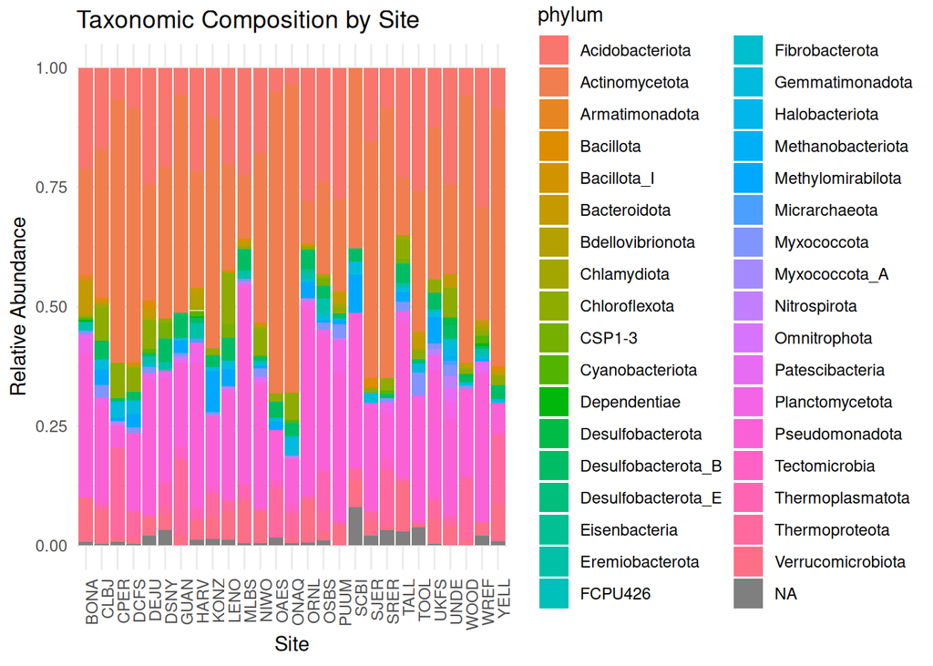

```r
# Summarize relative abundances of phyla across sites
taxa_summary <- soil_data %>%
  group_by(siteID, phylum) %>%
  summarise(count = n(), .groups = "drop") %>%
  group_by(siteID) %>%
  mutate(rel_abundance = count / sum(count))

# Plot phylum composition across sites
tax_plot <- ggplot(taxa_summary, aes(x = siteID, y = rel_abundance, fill = phylum)) +
  geom_bar(stat = "identity") +
  theme_minimal() +
  labs(title = "Taxonomic Composition by Site", x = "Site", y = "Relative Abundance") +
  theme(axis.text.x = element_text(angle = 90, hjust = 1))

print(tax_plot)
```

## 3. Alpha Diversity

Explanation: We compute diversity within each site:

Shannon Index (accounts for richness and evenness). Simpson Index (dominance measure). Richness (number of unique taxa).

Visualized as a bar chart of Shannon diversity per site.

Purpose: Assess how diverse each site’s microbial community is.

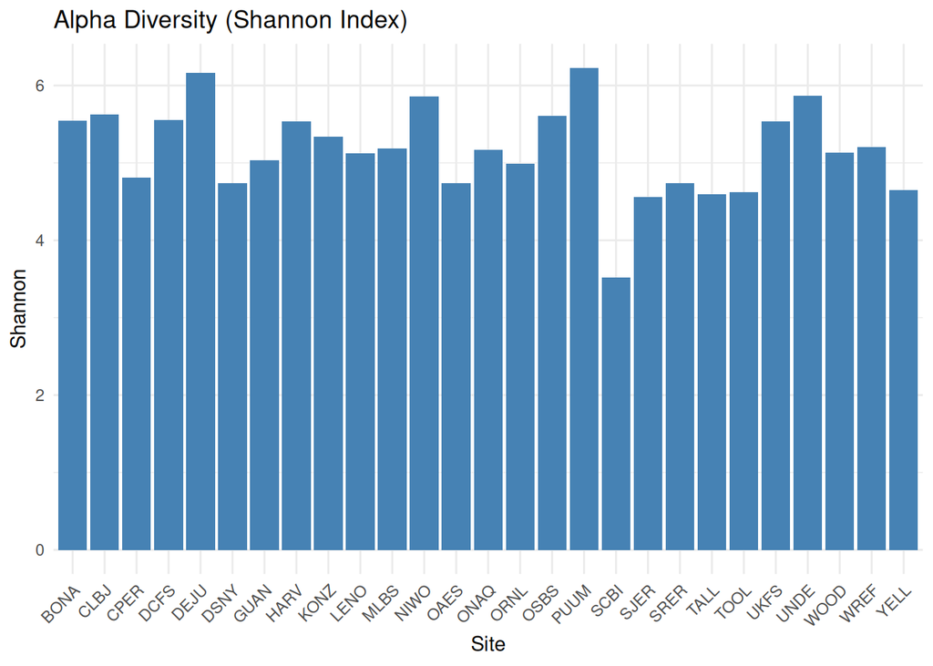

```r
# Create community matrix
comm_matrix <- soil_data %>%
  group_by(siteID, bin_id) %>%
  summarise(count = n(), .groups = "drop") %>%
  pivot_wider(names_from = bin_id, values_from = count, values_fill = 0)

# Compute diversity metrics
shannon <- diversity(as.matrix(comm_matrix[,-1]), index = "shannon")
simpson <- diversity(as.matrix(comm_matrix[,-1]), index = "simpson")
richness <- rowSums(comm_matrix[,-1] > 0)

alpha_df <- data.frame(siteID = comm_matrix$siteID, Shannon = shannon, Simpson = simpson, Richness = richness)

# Plot Shannon diversity
alpha_plot <- ggplot(alpha_df, aes(x = siteID, y = Shannon)) +
  geom_bar(stat = "identity", fill = "steelblue") +
  theme_minimal() +
  labs(title = "Alpha Diversity (Shannon Index)", x = "Site", y = "Shannon") +
  theme(axis.text.x = element_text(angle = 45, hjust = 1))

print(alpha_plot)
```

## 4. Beta Diversity

Explanation: We measure differences between sites using Bray-Curtis dissimilarity:

Perform NMDS ordination to reduce dimensionality. Plot sites in ordination space (closer points = more similar communities). Provide both static ggplot and interactive plotly versions.

Purpose: Reveal patterns of community similarity across sites.

```r
# Compute Bray-Curtis dissimilarity
bray_dist <- vegdist(as.matrix(comm_matrix[,-1]), method = "bray")

# NMDS ordination
nmds <- metaMDS(as.matrix(comm_matrix[,-1]), distance = "bray", k = 2, trymax = 100)
```

```
*** Best solution was not repeated -- monoMDS stopping criteria:
   100: stress < smin
```

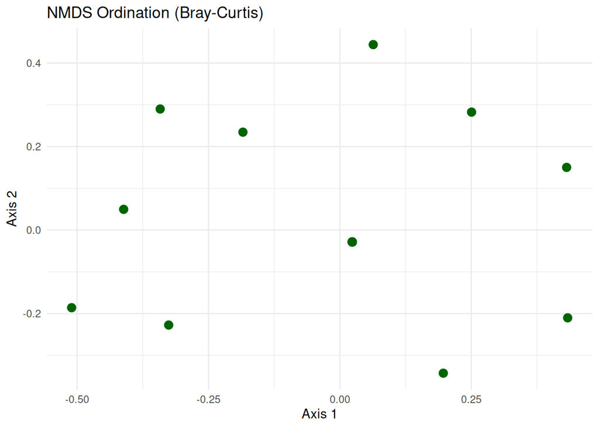

```r
nmds_points <- as.data.frame(nmds$points)
nmds_points$siteID <- rownames(nmds_points)

# Static NMDS plot
nmds_plot <- ggplot(nmds_points, aes(x = MDS1, y = MDS2, text = siteID)) +
  geom_point(color = "darkgreen", size = 3) +
  theme_minimal() +
  labs(title = "NMDS Ordination (Bray-Curtis)", x = "Axis 1", y = "Axis 2")

print(nmds_plot)
```

```r
# Interactive NMDS plot
nmds_interactive <- ggplotly(nmds_plot, tooltip = "text")
nmds_interactive
```

[interactive chart not shown]

## 5. PCoA

Explanation: We run Principal Coordinates Analysis (PCoA) on the same Bray-Curtis matrix:

Extract first two axes. Plot sites in ordination space. Provide static and interactive plots.

Purpose: Complement NMDS with another ordination method for robustness.

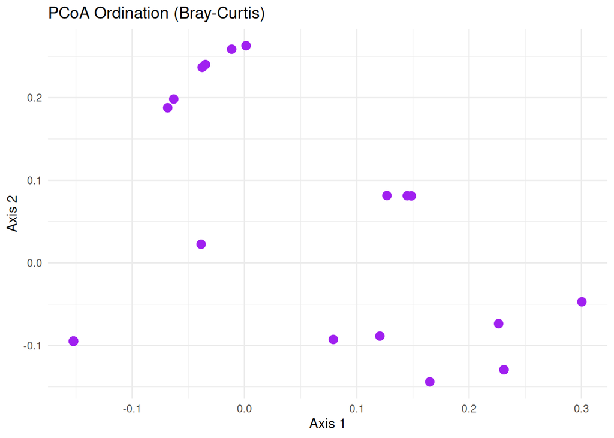

```r
# PCoA using Bray-Curtis
pcoa_result <- ape::pcoa(bray_dist)
pcoa_df <- data.frame(Axis1 = pcoa_result$vectors[,1], Axis2 = pcoa_result$vectors[,2], siteID = rownames(pcoa_result$vectors))

# Static PCoA plot
pcoa_plot <- ggplot(pcoa_df, aes(x = Axis1, y = Axis2, text = siteID)) +
  geom_point(color = "purple", size = 3) +
  theme_minimal() +
  labs(title = "PCoA Ordination (Bray-Curtis)", x = "Axis 1", y = "Axis 2")

print(pcoa_plot)
```

```r
# Interactive PCoA plot
pcoa_interactive <- ggplotly(pcoa_plot, tooltip = "text")
pcoa_interactive
```

[interactive chart not shown]

## Key Insights

Taxonomic Composition: Microbial communities differ substantially across sites, with certain phyla dominating specific locations, indicating ecological specialization.

Interactive Exploration: Plotly-based interactive ordination plots allow dynamic investigation of site-level differences, enhancing interpretability and enabling deeper insights.

Overall Pattern: Microbial diversity and composition are not uniform across sites, highlighting the importance of spatial and environmental factors in shaping microbial ecosystems.